# Complexite algorithmique

## Introduction a la theorie de la complexite algorithmique

L'example suivant represente une implementation de l'algorithme du tri a bulles en Python. Le programme sera execute et evalue pour plusieurs tailles du tableau.

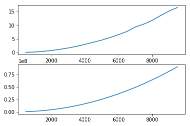

```python
import timeit
import random
import matplotlib.pyplot as plt
import numpy as np

def create_xs(n):
    xs = []
    for i in range(n):
        x = random.randrange(n)
        xs.append(x)
    return xs

def create_xs2(n):
    xs = [k for k in range(n)]
    return xs

def cent(number):
    if number % 500 ==0:
        return True
    else:
        return False


cases_array = np.array([k for k in range(1,10000) if cent(k)])
ca_squared = cases_array ** 2
times = []

bubble_sort = """
t = {}
x = 0
for j in range(len(t)-1):
    for i in range(len(t)-1):
        if t[i] < t[i+1]:
            x = t[i]
            t[i] = t[i+1]
            t[i+1] = x
"""

for i in cases_array:
    arr = create_xs2(i)
    ex_time = timeit.timeit(bubble_sort.format(arr),number=1)
    times.append(ex_time)


fig = plt.figure()

ax1 = fig.add_subplot(211)
ax2 = fig.add_subplot(212)

ax1.plot(cases_array, times)
ax2.plot(cases_array, ca_squared)

plt.show()
```

L'example suivant represente une implementation de l'algorithme de la recherche dichotomique en Python. Le programme sera execute et evalue pour plusieurs tailles du tableau.

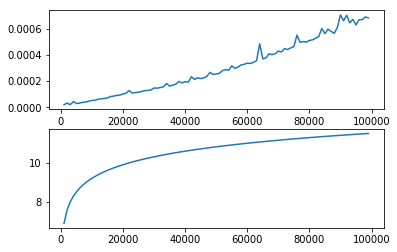

```python
import timeit
import random
import matplotlib.pyplot as plt
import numpy as np

def create_xs(n):
    xs = []
    for i in range(n):
        x = random.randrange(n)
        xs.append(x)
    return xs

def create_xs2(n):
    xs = [k for k in range(n)]
    return xs

def cent(number):
    if number % 1000 ==0:
        return True
    else:
        return False


cases_array = np.array([k for k in range(1,100000) if cent(k)])
ca_squared = np.log(cases_array)
times = []


binary_search = """
arr = {}
what = 500
li,ls = 0, len(arr) -1
found = -1

while li<=ls:
      middle = (li+ls)//2
      if(what == arr[middle]):
         found = middle
         break;
      elif what > arr[middle]:
         li = middle + 1
      else:
         ls = middle - 1

"""

for i in cases_array:
    arr = create_xs2(i)
    what = 500
    ex_time = timeit.timeit(binary_search.format(arr), number=1)
    times.append(ex_time)

fig = plt.figure()

ax1 = fig.add_subplot(211)
ax2 = fig.add_subplot(212)

ax1.plot(cases_array, times)
ax2.plot(cases_array, ca_squared)

plt.show()
```

/!\ La recherche dichotomique s'execute tres rapidement pour des inputs de taille tres grande.

### Exercices resolus :

Calculez la complexite des algorithmes suivante :

#### Algorithme 1

1. algorithme

```
function(int n)
    {
        if (n==1)
           return;
        for (int i=1; i<=n; i++)
        {
            for (int j=1; j<=n; j++)
            {
                printf("*");
                break;
            }
        }
    }
```

1. Complexite : $$ O(n) $$
2. Solution Detailee :

La boucle `for` imbriquee (la deuxieme) tourne une seule fois puis il il retourne l'execution a la boucle parent. Ceci est du a l'existance du `break` La boucle a exterieure s'execute $n$ fois pour chaque $n$. Donc l'algorithme est de complexite $O(n)$

#### Algorithme 2

1. algorithme

```
void function(int n)
    {
        int count = 0;
        for (int i=n/2; i<=n; i++)
            for (int j=1; j<=n; j = 2 * j)
                for (int k=1; k<=n; k = k * 2)
                    count++;
    }
```

1. Complexite : $$ O(nlog^2(n)) $$
2. Solution Detaillee :
   - Analyse de la boucle `for (int k=1; k<=n; k = k * 2)` :

Soit $K_i$ la suite qui reprente la valeur de la variable $k \forall$ iteration $i$, on a :

$$ K_0 = 1, K_1 = K_0 * 2, K_2 = K_0 * 2 * 2, ... K_i = K_0 * 2^i ... K_l = K_0 * 2^l $$

*(avec l le nombre d'iterations effectue par la boucle)*

Pour le $l$ limite (le nombre d'iterations effectuees dans notre cas) On a l est le plus petit nombre entier tel que:

$$ K_l < n $$

ou encore $$ 2^l < n $$ $$ l < log(n) $$

- Analyse de l'algorithme complet :

La boucle exterieur s'execute en $\frac{n}{2}$ iterations( $O(n)$ ), la deuxieme est similaire a la 3eme d'ou la complexite de l'agorithme complet est d'ordre de $nlog^2(n)$

#### Algorithme 3

1. algorithme

```
void function(int n)
    {
        int i = 1, s =1;
        while (s <= n)
        {
            i++;
            s += i;
            printf("*");
        }
    }
```

1. Complexite : $$ O(\sqrt{n}) $$
2. Solution Detaillee :

Soit $S_i$ la suite qui reprente la valeur de la variable $s \forall$ iteration $i$, on a :

$$ S_0 = 1, S_1 = S_0 + 1, S_2 = S_0 + 1 + 2, ... S_i = S_0 + \sum_{k=1}^{i} k ... S_l = S_0 + \sum_{k=1}^{l} k $$

*(avec l le nombre d'iterations effectue par la boucle)*

Pour le $l$ limite (le nombre d'iterations effectuees dans notre cas) On a l est le plus petit nombre entier tel que:

$$ S_l < n $$

ou encore $$ 1 + \sum_{k=1}^{l} k < n $$ $$ 1 + \frac{l(l+1)}{2} < n $$ Pour determiner l'ordre de complexite du programme, il faut resoudre l'inegalite. (factoristion/forme canonique ou en calculant le $\delta$. Il est bien evident que le resultat obtenu sera d'ordre $O(\sqrt{n})$

### Exercices non resolus (similaire):

#### Algorithme 1

```
void function(int n)
    {
        int count = 0;
        for (int i=n/2; i<=n; i++)
            for (int j=1; j+n/2<=n; j = j++)
                for (int k=1; k<=n; k = k * 2)
                    count++;
    }
```

#### Algorithme 2

```
void function(int n)
    {
        int count = 0;
        for (int i=count; i<=n; i++)
            for (int j=1; j<=i; j = j++)
                count++;
    }
```

### Exercices Bonus

#### Algorithme 1

```
void function(int n)
    {
        int count = 0;
        for (int i=0; i<n; i++)
            for (int j=i; j< i*i; j++)
                if (j%i == 0)
                {
                    for (int k=0; k<j; k++)
                        printf("*");
                }
    }
```

#### Algorithme 2

```
for (int i = 2; i <=n; i = pow(i, 5)) { // pow(i,5) <=> i a la puissance 5 <=> i^5
       printf("*");
   }
```

#### Algorithme 3

```
void fun()
{
   int i, j;
   for (i=1; i<=n; i++)
      for (j=1; j<=log(i); j++)
         printf("*");
}
```